# Finding love in the age of big data

Marc Garcia, Senior Data Scientist

**PyCon Poland 2017**

## @datapythonista

[figure not shown]

## This is Richard

[figure not shown]

## This is Richard

- **Age:** 22 year old
- **Job:** Java developer
- **Hobbies:** Tree climbing, ant hunting
- **His dream:** Get married and have children

[figure not shown]

## Can we help Richard?

With Python and Data

## We've got an app

With more than 350 million registered users

[figure not shown]

## Will Richard find his soulmate?

## How can we help him using data?

## Agenda

- **Data quality**
- Tools
- Machine learning

# "Data scientists spend 95% of the time cleaning data"

The other 5% is spent complaining about cleaning data

[figure not shown]

## Data at scale

300+ event types

6,000,000,000+ events / day

## Can we understand what we save?

| user_id | enc_prof_disp |
| --- | --- |
| 49395273901955084 | True |
| 78373697323880261 | False |
| 88880386797307883 | False |
| 50773938048630964 | False |
| 71873231699251735 | True |
| 10189017089470557 | False |

[figure not shown]

## enc_prof_disp

Encounters, profile displayed

This event tells whether the user clicked on the user description box, to expand it, and see all the information related to the profile.

- **Implemented date:** 2011-07-23
- **Deprecated date:** N/A
- **Platform:** iOS, Android
- **Owner:** UX team
- **Type:** Boolean

## Can we join our own data?

#### Table 1

| country |
| --- |
| 616 |

#### Table 2

| country |
| --- |
| POL |

#### Table 3

| country |
| --- |
| pl |

## SQL vs noSQL

[figure not shown]

## Data teams

- Infrastructure: Sysadmins, DBAs, Big Data specialists, ETL engineers, Software developers
- BI specialists
- Business analysts
- Data analysts
- Data scientists

## Takeaways

- Democratize all the data you save
- Standardization / Integrity / Metadata
- Don't underestimate: infrastructure / team

## Agenda

- Data quality
- **Tools**
- Machine learning
- Readability
- Batteries included
- Great community
- ...

[figure not shown]

## Is Python fast?

## Are computers fast?

[figure not shown]

## What's "wrong" with Python?

Besides the GIL

[figure not shown]

| Static types Contiguous memory |  |
| --- | --- |

| Static types Contiguous memory **Optimized for computation** |  |
| --- | --- |

```python
import numpy

large_list = list(range(10_000_000))
large_list_numpy = numpy.array(large_list)

print('Python:')
%time result = sum(large_list)

print('\nnumpy:')
%time result = large_list_numpy.sum()
```

```
Python:
CPU times: user 71.2 ms, sys: 1.54 ms, total: 72.7 ms
Wall time: 72.5 ms

numpy:
CPU times: user 6.09 ms, sys: 74 µs, total: 6.16 ms
Wall time: 5.9 ms
```

```python
large_list ** 2
```

```
---------------------------------------------------------------------------
TypeError                                 Traceback (most recent call last)
<ipython-input-183-04ba34a4e8af> in <module>()
----> 1 large_list ** 2

TypeError: unsupported operand type(s) for ** or pow(): 'list' and 'int'
```

```python
print('Python:')
%time result = [x ** 2 for x in large_list]

print('\nnumpy:')
%time result = large_list_numpy ** 2
```

```
Python:
CPU times: user 2.72 s, sys: 167 ms, total: 2.89 s
Wall time: 2.91 s

numpy:
CPU times: user 113 ms, sys: 77.3 ms, total: 191 ms
Wall time: 191 ms
```

| Static types Contiguous memory Optimized for computation **Tabular data** |  |
| --- | --- |

```python
import datetime
import pandas

aleksandra = ('Aleksandra', datetime.datetime(1980, 7, 30),  1.68, 0, 1)
jakub      = ('Jakub',      datetime.datetime(1965, 10, 22), 1.75, 2, 0)

df = pandas.DataFrame([aleksandra, jakub],
                      columns=('name', 'dob', 'height', 'num_dogs', 'num_cats')).set_index('name')
df
```

| name | dob | height | num_dogs | num_cats |
| --- | --- | --- | --- | --- |
| Aleksandra | 1980-07-30 | 1.68 | 0 | 1 |
| Jakub | 1965-10-22 | 1.75 | 2 | 0 |

```python
df['num_pets'] = df['num_dogs'] + df['num_cats']

df['age'] = ((datetime.datetime.now() - df['dob']).dt.days / 365.25).astype(int)

df
```

| name | dob | height | num_dogs | num_cats | num_pets | age |
| --- | --- | --- | --- | --- | --- | --- |
| Aleksandra | 1980-07-30 | 1.68 | 0 | 1 | 1 | 37 |
| Jakub | 1965-10-22 | 1.75 | 2 | 0 | 2 | 51 |

```python
df[['height', 'num_pets']].mean()
```

```
height      1.715
num_pets    1.500
dtype: float64
```

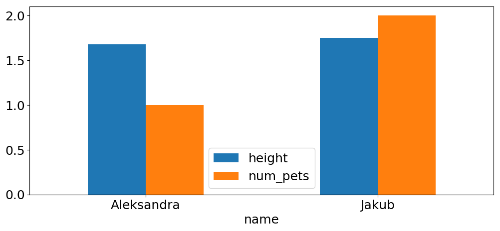

```python
import matplotlib.pyplot as plt

df[['height', 'num_pets']].plot(kind='bar')
plt.xticks(rotation=0);
```

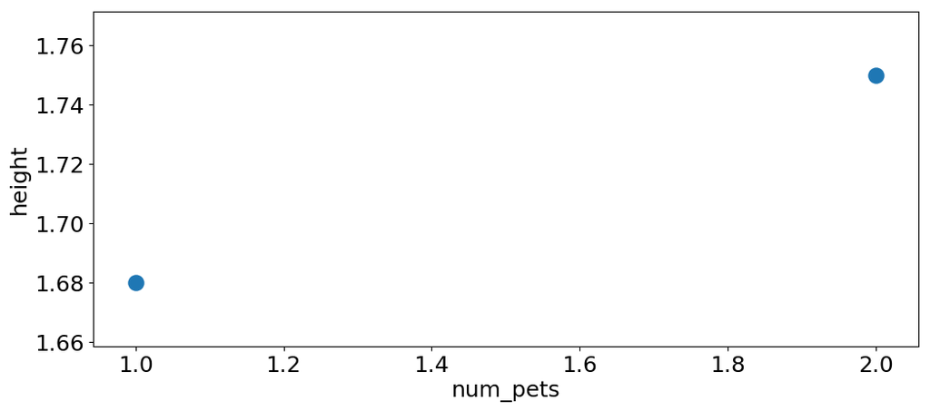

```python
df[['height', 'num_pets']].plot(kind='scatter', x='num_pets', y='height', s=150);
```

[figure not shown]

```python
import numpy
import sklearn.datasets
import sklearn.linear_model

diabetes = sklearn.datasets.load_diabetes()
x, y = diabetes.data[:, numpy.newaxis, 2], diabetes.target

linear_regression = sklearn.linear_model.LinearRegression()
linear_regression.fit(x, y)
```

```
LinearRegression(copy_X=True, fit_intercept=True, n_jobs=1, normalize=False)
```

## Visualization

[figure not shown]

HoloViews, Plotly, Seaborn, Folium, yt...

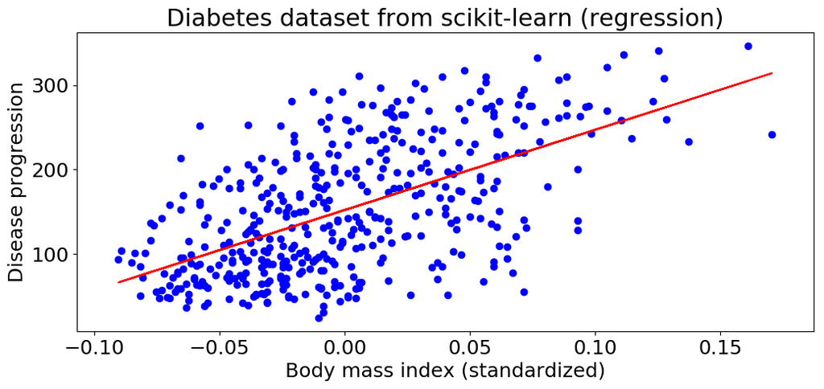

```python
import matplotlib.pyplot as plt

plt.title('Diabetes dataset from scikit-learn (regression)')
plt.xlabel('Body mass index (standardized)'); plt.ylabel('Disease progression')
plt.scatter(x, y,  color='blue')
plt.plot(x, linear_regression.predict(x), color='red')
plt.show()
```

## Big data

## Installing

`pip install <package-name>`

not so easy...

- C extensions
- Cython
- Binary dependencies

Procedure:

1. `pip install <package-name>`
2. Compilation error
3. Seach stackoverflow.com
4. `apt-get install <required-dev-package>`
5. Goto 1

[figure not shown]

`conda install <package-name>`

## Takeaways

- Python can be fast enough for data
- Tools available for mostly everything
- Easy to install and manage packages

## Agenda

- Data quality
- Tools
- **Machine learning**

## Agenda

- Data quality
- Tools
- Machine learning
  - **Supervised learning**
  - Bayesian methods
  - Deep learning

[figure not shown]

## What does Richard want?

[figure not shown]

| Name | Age | Liked? |
| --- | --- | --- |
| Zuzanna | 22 | No |
| Lena | 26 | Yes |
| Julia | 23 | No |
| Maja | 24 | No |
| Zofia | 28 | Yes |

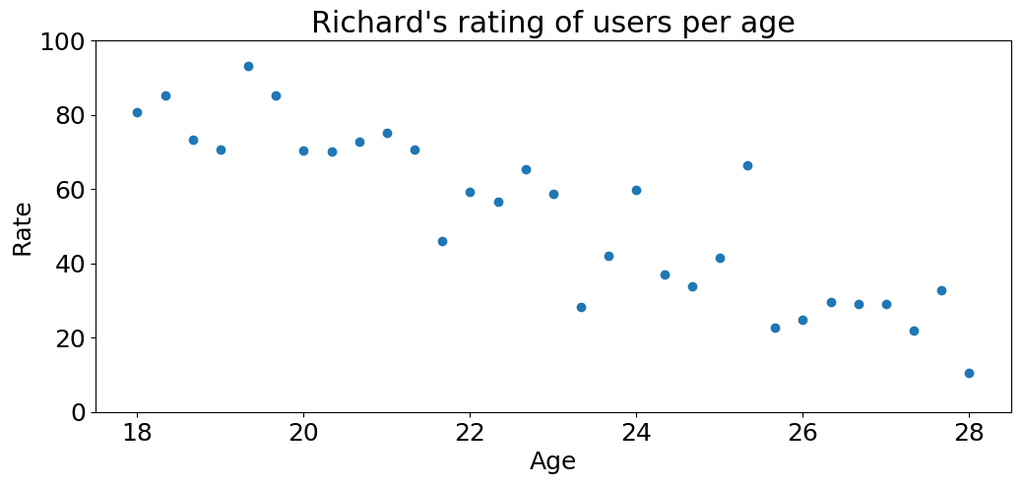

```python
import matplotlib.pyplot as plt

plt.title("Richard's rating of users per age")
plt.xlabel('Age'); plt.ylabel('Rate'); plt.ylim(0, 100)
plt.scatter(x, y);
```

```python
import sklearn.linear_model

linear_regression = sklearn.linear_model.LinearRegression()
linear_regression.fit(x.reshape([num_samples, 1]), y)
yhat_simple = linear_regression.predict(x.reshape([num_samples, 1]))
```

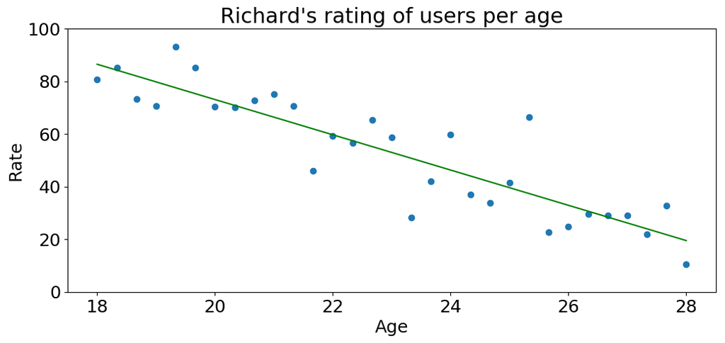

```python
plt.title("Richard's rating of users per age")
plt.xlabel('Age'); plt.ylabel('Rate'); plt.ylim(0, 100)
plt.scatter(x, y)
plt.plot(x, yhat_simple, color='g');
```

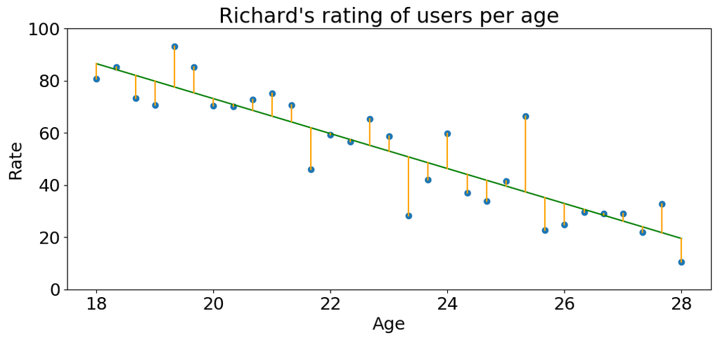

```python
plt.title("Richard's rating of users per age")
plt.xlabel('Age'); plt.ylabel('Rate'); plt.ylim(0, 100)
plt.scatter(x, y)
plt.plot(x, yhat_simple, color='g')
[plt.plot([x[i], x[i]], [y[i], yhat_simple[i]], color='orange') for i in range(0, num_samples)];
```

```python
import sklearn.tree

tree = sklearn.tree.DecisionTreeRegressor()
tree.fit(x.reshape([num_samples, 1]), y)
yhat_complex = tree.predict(x.reshape([num_samples, 1]))
```

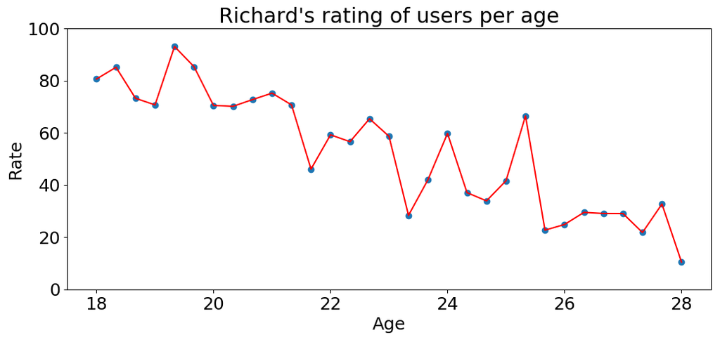

```python
plt.title("Richard's rating of users per age")
plt.xlabel('Age'); plt.ylabel('Rate'); plt.ylim(0, 100)
plt.scatter(x, y)
plt.plot(x, yhat_complex, color='r');
```

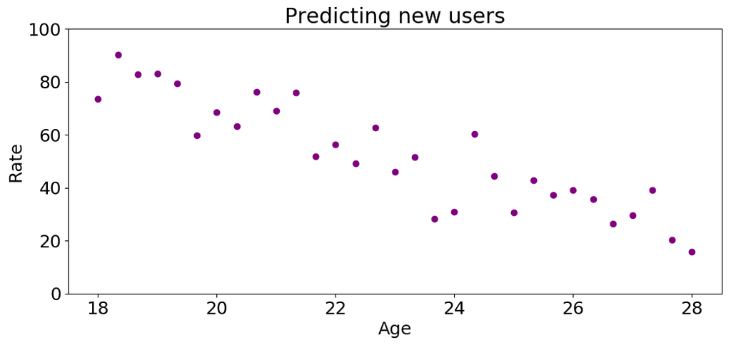

```python
plt.title('Predicting new users')
plt.xlabel('Age'); plt.ylabel('Rate'); plt.ylim(0, 100)
plt.scatter(x, y_new, color='purple');
```

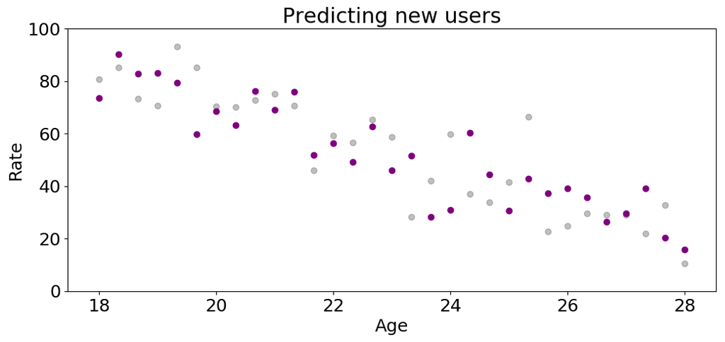

```python
plt.title('Predicting new users')
plt.xlabel('Age'); plt.ylabel('Rate'); plt.ylim(0, 100)
plt.scatter(x, y, color='gray', alpha=.5)
plt.scatter(x, y_new, color='purple');
```

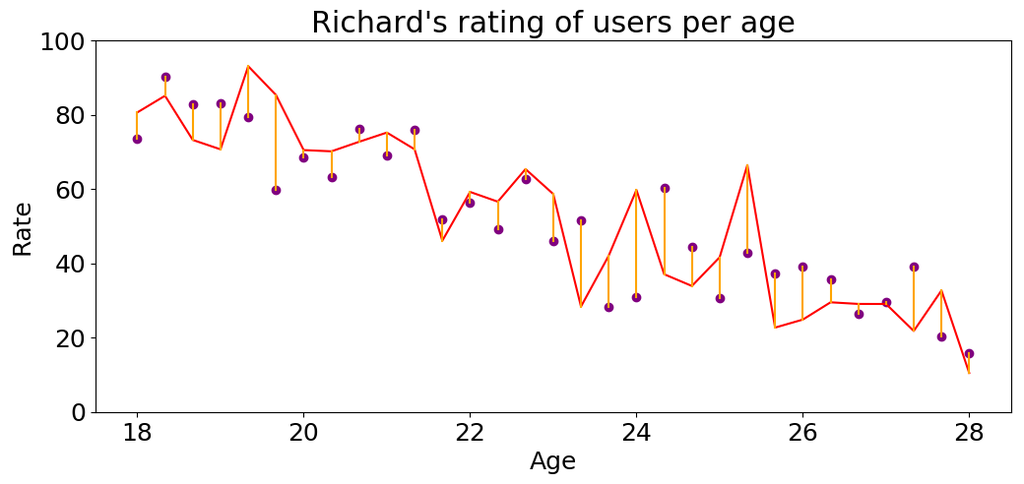

```python
plt.title("Richard's rating of users per age")
plt.xlabel('Age'); plt.ylabel('Rate'); plt.ylim(0, 100)
plt.scatter(x, y_new, color='purple')
plt.plot(x, yhat_complex, color='r')
[plt.plot([x[i], x[i]], [y_new[i], yhat_complex[i]], color='orange') for i in range(0, num_samples)];
```

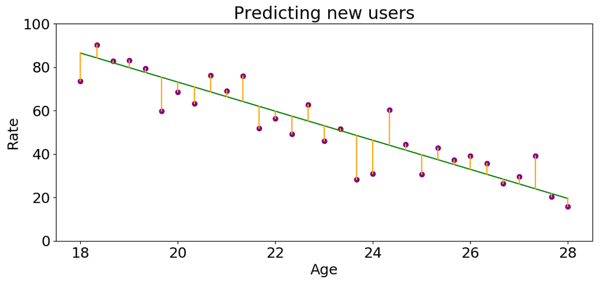

```python
plt.title('Predicting new users')
plt.xlabel('Age'); plt.ylabel('Rate'); plt.ylim(0, 100)
plt.scatter(x, y_new, color='purple')
plt.plot(x, yhat_simple, color='g')
[plt.plot([x[i], x[i]], [y_new[i], yhat_simple[i]], color='orange') for i in range(0, num_samples)];
```

[figure not shown]

William of Ockham, 1287 - 1347

## "Among competing hypotheses, the one with the fewest assumptions should be selected."

## Can we compute the probability of Richard liking every female user?

| Name | Age | Height | Will like? |
| --- | --- | --- | --- |
| Hanna | 25 | 1.63 | 0.43 |
| Amelia | 18 | 1.55 | 0.12 |
| Alicja | 27 | 1.76 | 0.87 |
| Natalia | 21 | 1.65 | 0.22 |
| Wiktoria | 28 | 1.58 | 0.95 |

```python
users.head()
```

| name | age | height | liked |
| --- | --- | --- | --- |
| Oliwia | 28 | 152 | True |
| Maria | 64 | 176 | False |
| Emilia | 45 | 169 | False |
| Nikola | 33 | 172 | False |
| Liliana | 19 | 170 | True |

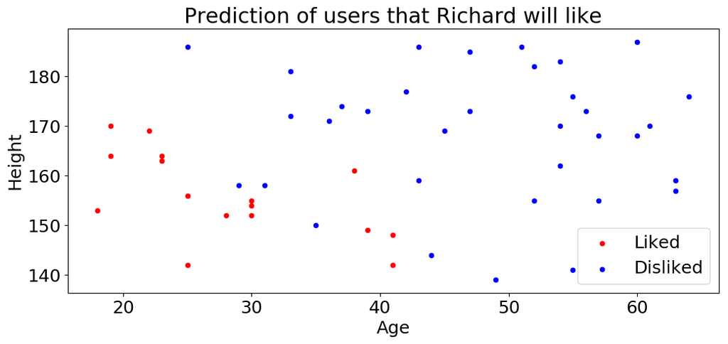

```python
import matplotlib.pyplot as plt

plt.scatter(users[users.liked]['age'], users[users.liked]['height'], color='r', s=20, label='Liked')
plt.scatter(users[~users.liked]['age'], users[~users.liked]['height'], color='b', s=20, label='Disliked')
plt.title('Prediction of users that Richard will like')
plt.xlabel('Age') ; plt.ylabel('Height') ; plt.legend(loc='lower right') ;
```

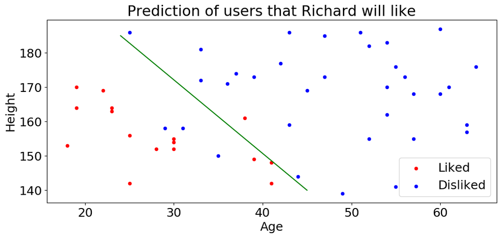

```python
import matplotlib.pyplot as plt

plt.scatter(users[users.liked]['age'], users[users.liked]['height'], color='r', s=20, label='Liked')
plt.scatter(users[~users.liked]['age'], users[~users.liked]['height'], color='b', s=20, label='Disliked')
plt.title('Prediction of users that Richard will like')
plt.xlabel('Age') ; plt.ylabel('Height') ; plt.legend(loc='lower right')
plt.plot([24, 45], [185, 140], color='g');
```

## Computing the decision boundary

- Logistic regression
- Linear support vector machine
- Linear discriminant analysis
- Perceptron
- ...

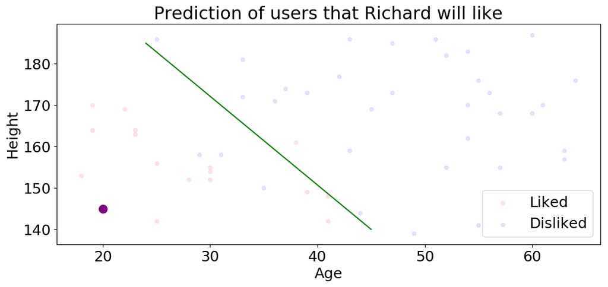

```python
import matplotlib.pyplot as plt

plt.scatter(users[users.liked]['age'], users[users.liked]['height'], color='r', s=20, label='Liked', alpha=.1)
plt.scatter(users[~users.liked]['age'], users[~users.liked]['height'], color='b', s=20, label='Disliked', alpha=.1)
plt.title('Prediction of users that Richard will like')
plt.xlabel('Age') ; plt.ylabel('Height') ; plt.legend(loc='lower right')
plt.plot([24, 45], [185, 140], color='g')
plt.scatter([20], [145], s=100, color='purple');
```

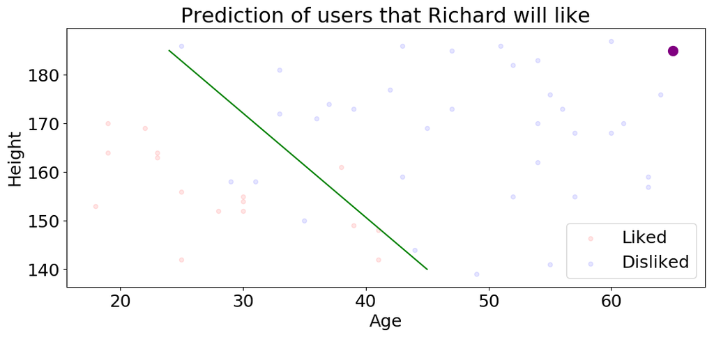

```python
import matplotlib.pyplot as plt

plt.scatter(users[users.liked]['age'], users[users.liked]['height'], color='r', s=20, label='Liked', alpha=.1)
plt.scatter(users[~users.liked]['age'], users[~users.liked]['height'], color='b', s=20, label='Disliked', alpha=.1)
plt.title('Prediction of users that Richard will like')
plt.xlabel('Age') ; plt.ylabel('Height') ; plt.legend(loc='lower right')
plt.plot([24, 45], [185, 140], color='g')
plt.scatter([65], [185], s=100, color='purple');
```

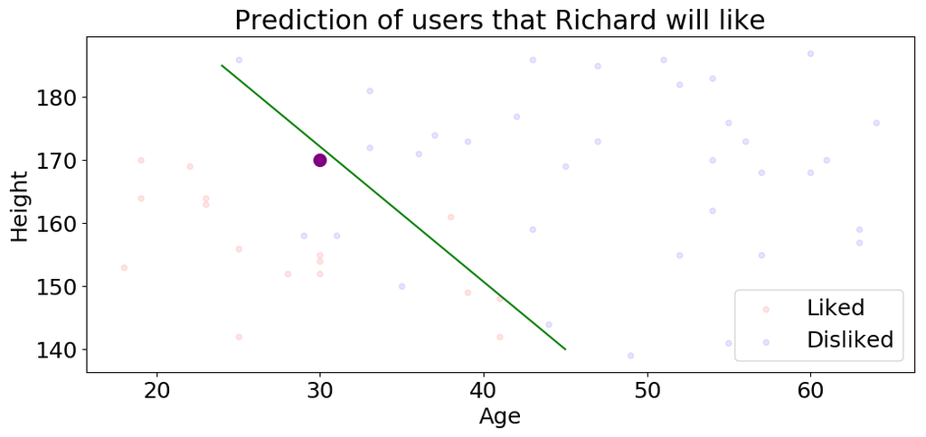

```python
import matplotlib.pyplot as plt

plt.scatter(users[users.liked]['age'], users[users.liked]['height'], color='r', s=20, label='Liked', alpha=.1)
plt.scatter(users[~users.liked]['age'], users[~users.liked]['height'], color='b', s=20, label='Disliked', alpha=.1)
plt.title('Prediction of users that Richard will like')
plt.xlabel('Age') ; plt.ylabel('Height') ; plt.legend(loc='lower right')
plt.plot([24, 45], [185, 140], color='g')
plt.scatter([30], [170], s=100, color='purple');
```

## We can make predictions

But also give uncertainty (probabilities)

## So easy?

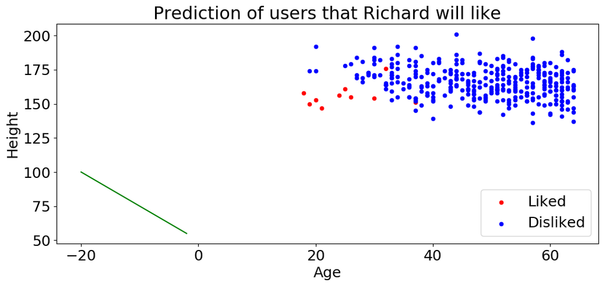

```python
import matplotlib.pyplot as plt

plt.scatter(users[users.liked]['age'], users[users.liked]['height'], color='r', s=20, label='Liked')
plt.scatter(users[~users.liked]['age'], users[~users.liked]['height'], color='b', s=20, label='Disliked')
plt.title('Prediction of users that Richard will like')
plt.xlabel('Age') ; plt.ylabel('Height') ; plt.legend(loc='lower right')
plt.plot([-20, -2], [100, 55], color='g');
```

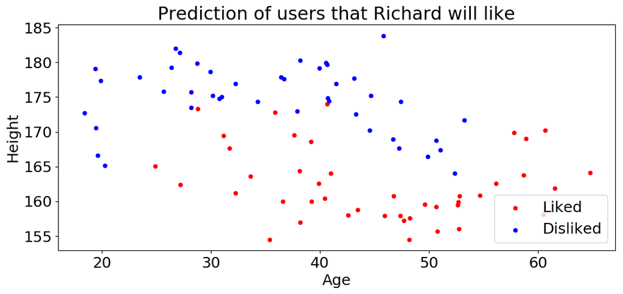

```python
import matplotlib.pyplot as plt

plt.scatter(users[users.liked]['age'], users[users.liked]['height'], color='r', s=20, label='Liked')
plt.scatter(users[~users.liked]['age'], users[~users.liked]['height'], color='b', s=20, label='Disliked')
plt.title('Prediction of users that Richard will like')
plt.xlabel('Age') ; plt.ylabel('Height') ; plt.legend(loc='lower right');
```

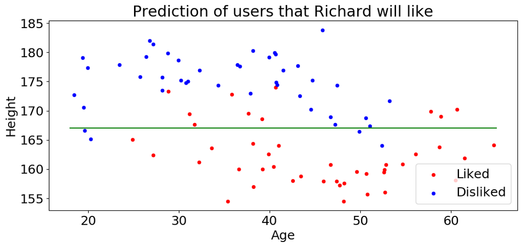

```python
import matplotlib.pyplot as plt

plt.scatter(users[users.liked]['age'], users[users.liked]['height'], color='r', s=20, label='Liked')
plt.scatter(users[~users.liked]['age'], users[~users.liked]['height'], color='b', s=20, label='Disliked')
plt.title('Prediction of users that Richard will like')
plt.xlabel('Age') ; plt.ylabel('Height') ; plt.legend(loc='lower right')
plt.plot([18, 65], [167, 167], color='g');
```

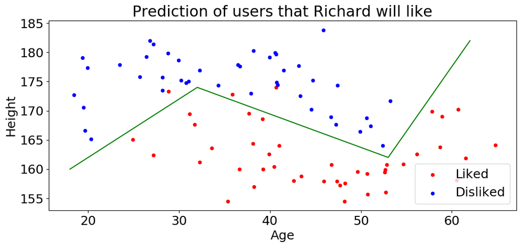

```python
import matplotlib.pyplot as plt

plt.scatter(users[users.liked]['age'], users[users.liked]['height'], color='r', s=20, label='Liked')
plt.scatter(users[~users.liked]['age'], users[~users.liked]['height'], color='b', s=20, label='Disliked')
plt.title('Prediction of users that Richard will like')
plt.xlabel('Age') ; plt.ylabel('Height') ; plt.legend(loc='lower right')
plt.plot([18, 32, 53, 62], [160, 174, 162, 182], color='g');
```

## Solutions

#### Overfitting

- Regularization
- Cross-validation
- Simpler models
- Use more data
- Ensembles
- Shrinkage

#### Imbalanced data

- Sample weighting
- Subsampling
- Custom loss functions
- Specialized metrics

#### Non-linear data

- Non-linear transformation
- Polynomial features
- Kernels
- Non-linear models

## What the industry is mainly doing?

[figure not shown]

```python
from sklearn.tree import DecisionTreeClassifier

decision_tree = DecisionTreeClassifier(criterion='entropy')
decision_tree.fit(users[['age', 'height']], users['liked'])
```

```
DecisionTreeClassifier(class_weight=None, criterion='entropy', max_depth=None,
            max_features=None, max_leaf_nodes=None,
            min_impurity_split=1e-07, min_samples_leaf=1,
            min_samples_split=2, min_weight_fraction_leaf=0.0,
            presort=False, random_state=None, splitter='best')
```

[figure not shown]

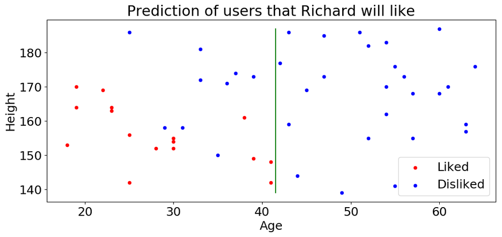

```python
import matplotlib.pyplot as plt

plt.scatter(users[users.liked]['age'], users[users.liked]['height'], color='r', s=20, label='Liked')
plt.scatter(users[~users.liked]['age'], users[~users.liked]['height'], color='b', s=20, label='Disliked')
plt.title('Prediction of users that Richard will like')
plt.xlabel('Age') ; plt.ylabel('Height') ; plt.legend(loc='lower right')
for x, y in decision_tree_boundaries(decision_tree, users, 'age', 'height', 'liked', limit=1):
    plt.plot(x, y, color='g')
```

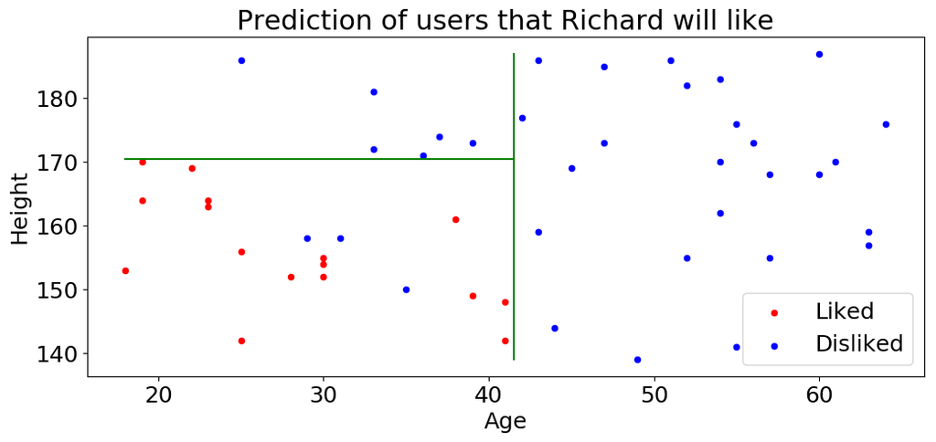

```python
import matplotlib.pyplot as plt

plt.scatter(users[users.liked]['age'], users[users.liked]['height'], color='r', s=20, label='Liked')
plt.scatter(users[~users.liked]['age'], users[~users.liked]['height'], color='b', s=20, label='Disliked')
plt.title('Prediction of users that Richard will like')
plt.xlabel('Age') ; plt.ylabel('Height') ; plt.legend(loc='lower right')
for x, y in decision_tree_boundaries(decision_tree, users, 'age', 'height', 'liked', limit=2):
    plt.plot(x, y, color='g')
```

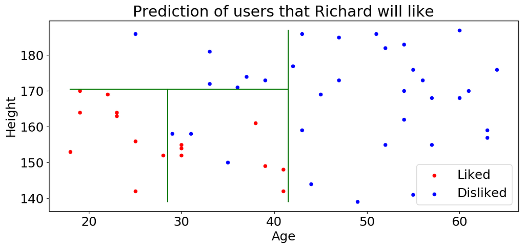

```python
import matplotlib.pyplot as plt

plt.scatter(users[users.liked]['age'], users[users.liked]['height'], color='r', s=20, label='Liked')
plt.scatter(users[~users.liked]['age'], users[~users.liked]['height'], color='b', s=20, label='Disliked')
plt.title('Prediction of users that Richard will like')
plt.xlabel('Age') ; plt.ylabel('Height') ; plt.legend(loc='lower right')
for x, y in decision_tree_boundaries(decision_tree, users, 'age', 'height', 'liked', limit=3):
    plt.plot(x, y, color='g')
```

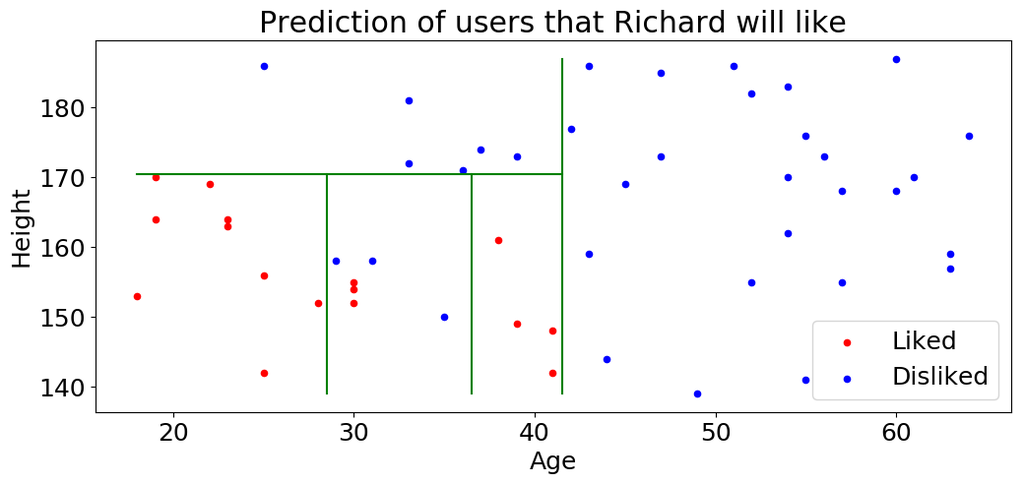

```python
import matplotlib.pyplot as plt

plt.scatter(users[users.liked]['age'], users[users.liked]['height'], color='r', s=20, label='Liked')
plt.scatter(users[~users.liked]['age'], users[~users.liked]['height'], color='b', s=20, label='Disliked')
plt.title('Prediction of users that Richard will like')
plt.xlabel('Age') ; plt.ylabel('Height') ; plt.legend(loc='lower right')
for x, y in decision_tree_boundaries(decision_tree, users, 'age', 'height', 'liked', limit=4):
    plt.plot(x, y, color='g')
```

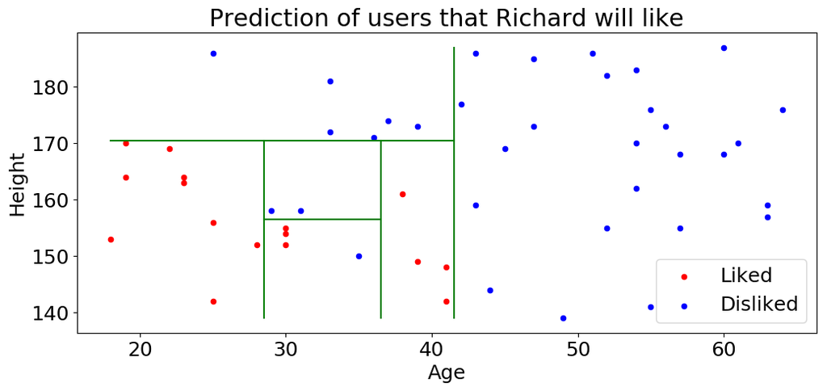

```python
import matplotlib.pyplot as plt

plt.scatter(users[users.liked]['age'], users[users.liked]['height'], color='r', s=20, label='Liked')
plt.scatter(users[~users.liked]['age'], users[~users.liked]['height'], color='b', s=20, label='Disliked')
plt.title('Prediction of users that Richard will like')
plt.xlabel('Age') ; plt.ylabel('Height') ; plt.legend(loc='lower right')
for x, y in decision_tree_boundaries(decision_tree, users, 'age', 'height', 'liked', limit=5):
    plt.plot(x, y, color='g')
```

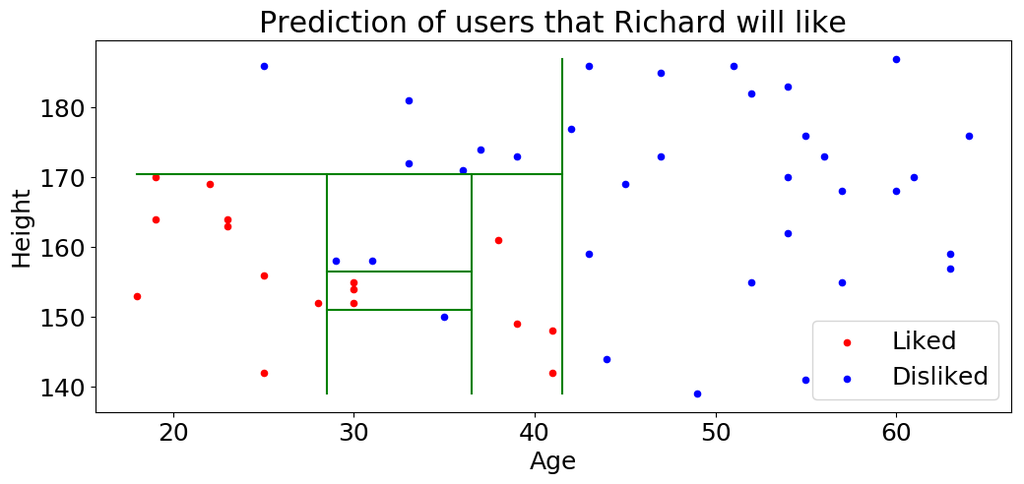

```python
import matplotlib.pyplot as plt

plt.scatter(users[users.liked]['age'], users[users.liked]['height'], color='r', s=20, label='Liked')
plt.scatter(users[~users.liked]['age'], users[~users.liked]['height'], color='b', s=20, label='Disliked')
plt.title('Prediction of users that Richard will like')
plt.xlabel('Age') ; plt.ylabel('Height') ; plt.legend(loc='lower right')
for x, y in decision_tree_boundaries(decision_tree, users, 'age', 'height', 'liked', limit=6):
    plt.plot(x, y, color='g')
```

[figure not shown]

```python
import sklearn.ensemble

random_forest = sklearn.ensemble.RandomForestClassifier(criterion='entropy',
                                                        n_estimators=3)
random_forest.fit(users[['age', 'height']], users['liked'])
```

```
RandomForestClassifier(bootstrap=True, class_weight=None, criterion='entropy',
            max_depth=None, max_features='auto', max_leaf_nodes=None,
            min_impurity_split=1e-07, min_samples_leaf=1,
            min_samples_split=2, min_weight_fraction_leaf=0.0,
            n_estimators=3, n_jobs=1, oob_score=False, random_state=None,
            verbose=0, warm_start=False)
```

[figure not shown]

## xgboost

[figure not shown]

## What if we show Richard all the users he will like the most?

| Name | Age | Height | Will like? |
| --- | --- | --- | --- |
| Ewa | 25 | 1.63 | 0.99 |
| Eliza | 23 | 1.55 | 0.99 |
| Kamila | 27 | 1.58 | 0.98 |
| Matylda | 24 | 1.61 | 0.96 |
| Olga | 28 | 1.56 | 0.94 |
| Kalina | 31 | 1.67 | 0.94 |

[figure not shown]

## Takeaways

- To use supervised learning we need labelled data
- Building models is easy, but is easy to encounter problems
  - Overfitting
  - Imbalanced datasets
  - Non-linear problems
- It is usually easier to get good results with trees

## Agenda

- Data quality
- Tools
- Machine learning
  - Supervised learning
  - **Bayesian methods**
  - Deep learning

## Will Richard's soulmate like him?

[figure not shown]

Can we help?

## How much a picture will be liked?

We show a picture 100 times

It is liked 30 times

The empirical probability is 0.30

## Classical school

Let us understand the pictures, in order to find a **mathematical model** on how much it will be liked.

## Frequentist school

Do we have **statistical significance** to say that at **infinity** probability will also be 0.30?

## Bayesian school

Let us model the **uncertainty**.

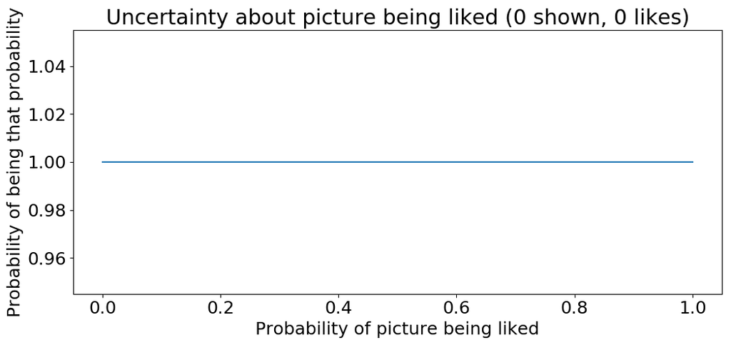

```python
import numpy
import scipy.stats
import matplotlib.pyplot as plt

x = numpy.linspace(0., 1., 1001)
y = scipy.stats.beta.pdf(x, 1, 1)
plt.title('Uncertainty about picture being liked (0 shown, 0 likes)')
plt.xlabel('Probability of picture being liked'); plt.ylabel('Probability of being that probability')
plt.plot(x, y);
```

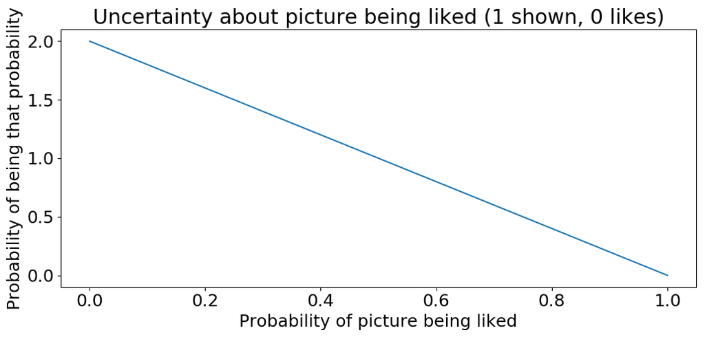

```python
import numpy
import scipy.stats
import matplotlib.pyplot as plt

x = numpy.linspace(0., 1., 1001)
y = scipy.stats.beta.pdf(x, 1, 2)
plt.title('Uncertainty about picture being liked (1 shown, 0 likes)')
plt.xlabel('Probability of picture being liked'); plt.ylabel('Probability of being that probability')
plt.plot(x, y);
```

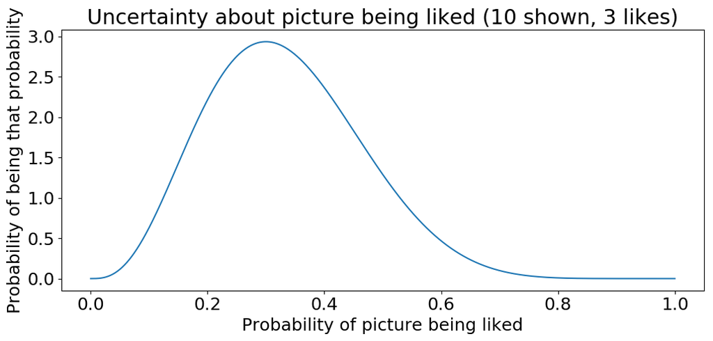

```python
import numpy
import scipy.stats
import matplotlib.pyplot as plt

x = numpy.linspace(0., 1., 1001)
y10 = scipy.stats.beta.pdf(x, 4, 8)
plt.title('Uncertainty about picture being liked (10 shown, 3 likes)')
plt.xlabel('Probability of picture being liked'); plt.ylabel('Probability of being that probability')
plt.plot(x, y10);
```

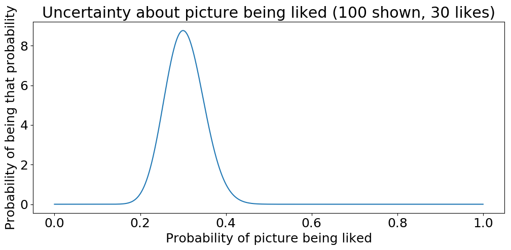

```python
import numpy
import scipy.stats
import matplotlib.pyplot as plt

x = numpy.linspace(0., 1., 1001)
y100 = scipy.stats.beta.pdf(x, 31, 71)
plt.title('Uncertainty about picture being liked (100 shown, 30 likes)')
plt.xlabel('Probability of picture being liked'); plt.ylabel('Probability of being that probability')
plt.plot(x, y100);
```

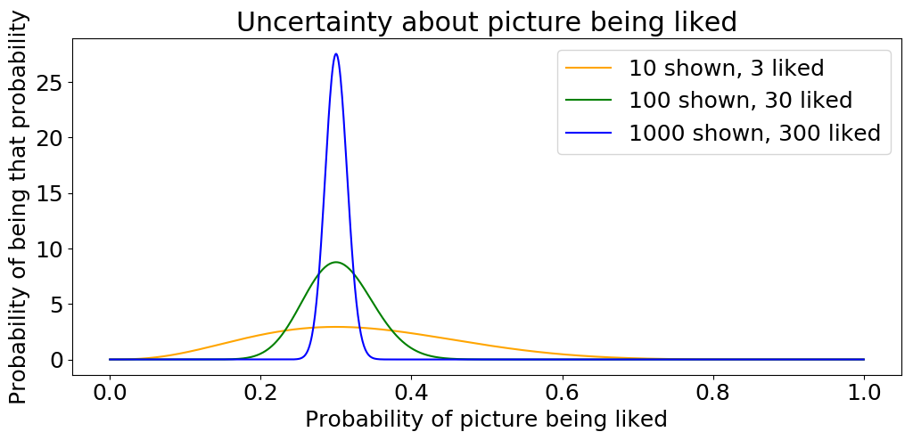

```python
y1000 = scipy.stats.beta.pdf(x, 301, 701)
plt.title('Uncertainty about picture being liked')
plt.xlabel('Probability of picture being liked'); plt.ylabel('Probability of being that probability')
plt.plot(x, y10, color='orange', label='10 shown, 3 liked')
plt.plot(x, y100, color='g', label='100 shown, 30 liked')
plt.plot(x, y1000, color='b', label='1000 shown, 300 liked')
plt.legend();
```

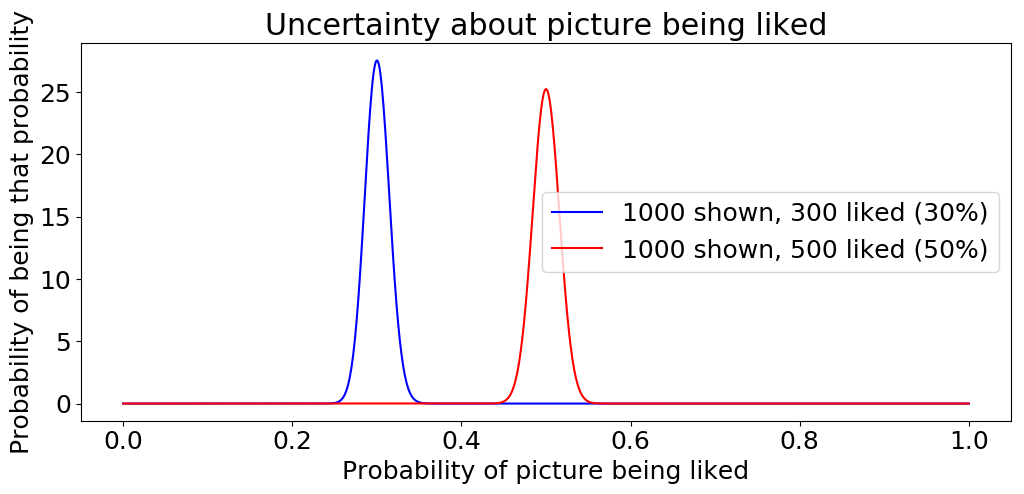

```python
y1000_50 = scipy.stats.beta.pdf(x, 501, 501)
plt.title('Uncertainty about picture being liked')
plt.xlabel('Probability of picture being liked'); plt.ylabel('Probability of being that probability')
plt.plot(x, y1000, color='b', label='1000 shown, 300 liked (30%)')
plt.plot(x, y1000_50, color='r', label='1000 shown, 500 liked (50%)')
plt.legend();
```

[figure not shown]

```python
random.seed(12345); numpy.random.seed(12345)
run_simulation(strategy=THOMPSON,
               names=('beer', 'sport', 'sunglasses', 'cats'),
               probabilities=(.07, .26, .18, .41))
```

[interactive chart not shown]

[figure not shown]

- No sunglasses
- No beers
- No friends
- No pictures from far away

[figure not shown]

## Takeaways

- Simple statistical models can be powerful
- It is good to consider uncertainty, and not ignore it
- Use pictures where you're visible, alone, and smiling :)

## Agenda

- Data quality
- Tools
- Machine learning
  - Supervised learning
  - Bayesian methods
  - **Deep learning**

## What is deep learning?

[figure not shown]

## What is deep learning?

[figure not shown]

## Takeaways

- Deep learning can do amazing things
- Complexity comes at a price
- Not for everyone, requires:
  - Lots of data
  - Lots of hardware
  - Lots of knowledge

## What happened with Richard?

- We found the best users based on his preferences
- We optimized his profile to be liked more
- We found users that look like the people he likes

[figure not shown]

# Well done Richard! :)